# Ford GoBike

## by Hassan Ibrahim

### Preliminary Wrangling

This dataset is provided by Ford Gobike from June 2017 to July 2018, which is the data of the bike rides in San Francisco Bay area. The data contains info about the rider and info about the ride path.

# Story behind this Analysis?

##### For sure all of us hates the traffic jam specially on rush hours, so why we dont save time, money and have some exersice while moving to work and bak to home! GoBike by Ford gives us this advantage by the bike sharing system, with thousands of public bikes for use across San Francisco, East Bay and San Jose. The bike share is designed with convenience in mind; it’s a fun and affordable way to get around town.

##### So it would be interesting to analyze the GoBike data to know who we should target in the future. In this analysis i will be focusing on two things:

##### 1-Who are using our bikes?

##### 2-When do they use them, are there any differences in use patterns?

```python
import pandas as pd
import numpy as np
import matplotlib.pyplot as plt
import seaborn as sb

%matplotlib inline
```

# Data Gathering

Data can be found on Gobike website https://www.fordgobike.com/system-data.

```python
# loading the 2017 data into a dataframe
df=pd.read_csv('2017-fordgobike-tripdata.csv')
```

```python
# loading the 2018 data from January to July.
for i in range(1,8):
    df2018=pd.read_csv('20180{}-fordgobike-tripdata.csv.zip'.format(i))
    df=df.append(df2018)
```

# Data Assessing and Cleaning

```python
# first 5 records
df.head()
```

|  | bike_id | bike_share_for_all_trip | duration_sec | end_station_id | end_station_latitude | end_station_longitude | end_station_name | end_time | member_birth_year | member_gender | start_station_id | start_station_latitude | start_station_longitude | start_station_name | start_time | user_type |
| --- | --- | --- | --- | --- | --- | --- | --- | --- | --- | --- | --- | --- | --- | --- | --- | --- |
| 0 | 96 | NaN | 80110 | 43.0 | 37.778768 | -122.415929 | San Francisco Public Library (Grove St at Hyde... | 2018-01-01 15:12:50.2450 | 1987.0 | Male | 74.0 | 37.776435 | -122.426244 | Laguna St at Hayes St | 2017-12-31 16:57:39.6540 | Customer |
| 1 | 88 | NaN | 78800 | 96.0 | 37.766210 | -122.426614 | Dolores St at 15th St | 2018-01-01 13:49:55.6170 | 1965.0 | Female | 284.0 | 37.784872 | -122.400876 | Yerba Buena Center for the Arts (Howard St at ... | 2017-12-31 15:56:34.8420 | Customer |
| 2 | 1094 | NaN | 45768 | 245.0 | 37.870348 | -122.267764 | Downtown Berkeley BART | 2018-01-01 11:28:36.8830 | NaN | NaN | 245.0 | 37.870348 | -122.267764 | Downtown Berkeley BART | 2017-12-31 22:45:48.4110 | Customer |
| 3 | 2831 | NaN | 62172 | 5.0 | 37.783899 | -122.408445 | Powell St BART Station (Market St at 5th St) | 2018-01-01 10:47:23.5310 | NaN | NaN | 60.0 | 37.774520 | -122.409449 | 8th St at Ringold St | 2017-12-31 17:31:10.6360 | Customer |
| 4 | 3167 | NaN | 43603 | 247.0 | 37.867789 | -122.265896 | Fulton St at Bancroft Way | 2018-01-01 02:29:57.5710 | 1997.0 | Female | 239.0 | 37.868813 | -122.258764 | Bancroft Way at Telegraph Ave | 2017-12-31 14:23:14.0010 | Subscriber |

```python
df.info()
```

```
<class 'pandas.core.frame.DataFrame'>
Int64Index: 1538086 entries, 0 to 199221
Data columns (total 16 columns):
bike_id                    1538086 non-null int64
bike_share_for_all_trip    1018386 non-null object
duration_sec               1538086 non-null int64
end_station_id             1532841 non-null float64
end_station_latitude       1538086 non-null float64
end_station_longitude      1538086 non-null float64
end_station_name           1532841 non-null object
end_time                   1538086 non-null object
member_birth_year          1400419 non-null float64
member_gender              1400760 non-null object
start_station_id           1532841 non-null float64
start_station_latitude     1538086 non-null float64
start_station_longitude    1538086 non-null float64
start_station_name         1532841 non-null object
start_time                 1538086 non-null object
user_type                  1538086 non-null object
dtypes: float64(7), int64(2), object(7)
memory usage: 199.5+ MB
```

-Start and end time should be datetime datatype

-member birth year should be Integer.

-add new column member_age.

-Create duration_min column

```python
sum(df.duplicated())
```

```
0
```

We dont have any duplicated Rows

```python
# converting start and endtime into datetime datatype
df['start_time']=pd.to_datetime(df['start_time'])
df['end_time']=pd.to_datetime(df['end_time'])
```

```python
# converting  member birth year into int and filling the missing records with 0
# filling the empty member_gender with unknown
df['member_birth_year']=df['member_birth_year'].fillna(0).astype(int)
df['member_gender'] = df['member_gender'].fillna(value = 'Unknown')
```

```python
#calculating the ages of the members when they took the ride
df['member_age']=df['start_time'].dt.year - df['member_birth_year']
```

```python
#adding a new colmn duration/min
df['duration_min']=df['duration_sec']/60
```

### What is the structure of your dataset?

This data set contains info about each bike ride and info about the rider for every single ride.

### What is/are the main feature(s) of interest in your dataset?

it would be interesting to study the charactaristics of the riders so we can know their need to increase the number of rides.

### What features in the dataset do you think will help support your investigation into your feature(s) of interest?

Everything related to the rider can help us to analyze and investigate their needs, such as user type, member gender, trip time and duration.

# Univariate Exploration

### How does the rides trend vary per gender?

###### To explore the riders gender i will be using the univariate countplot to plot the 'member_gender' variable.

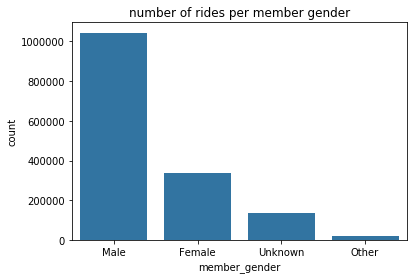

```python
clr=sb.color_palette()[0]
sb.countplot(data=df, x='member_gender', color=clr)
plt.title('number of rides per member gender');
```

This is clear that most of the riders are males with more than 1 million ride while the females around 300K.

### Which age preferred riding a bike?

##### As we are studying the characteristics for the bike riders, it is very important to know which age preffered riding a bike, to explore this i will use the matplotlib histogram.

```
Text(0.5,1,'Distribution of Member Age')
```

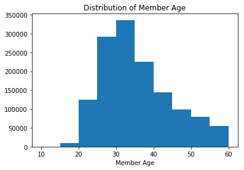

```python
bin_edges = np.arange(10, 60+5, 5)
plt.hist(data = df, x = 'member_age', bins=bin_edges);
plt.xlabel('Member Age')
plt.title('Distribution of Member Age')
```

This histogram shows that most of the riders are within age between 25 and 40 with higest at 30-35. The number of riders start decreasing as the age increase more than 40.

### How is the user type distibuted among the rides?

##### As we have more than 1.5 million record in our dataset, it is more effeciant to explore the user type using proportion. So I will use the seaborn countplot to plot the usertype in terms of proportion.

```python
type_counts=df['user_type'].value_counts()
n_type=df.shape[0]
max_type_counts=type_counts[0]
max_prop=max_type_counts/n_type
print(max_prop)
```

```
0.8236359995474896
```

```python
tick_prop=np.arange(0,max_prop+0.10,0.10)
tick_names=['{:0.2f}'.format(v) for v in tick_prop]
```

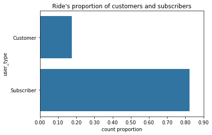

```python
sb.countplot(data=df, y='user_type', color=clr)
plt.xticks(tick_prop*n_type, tick_names)
plt.xlabel('count proportion')
plt.title("Ride's proportion of customers and subscribers");
```

The subscribed riders are around 80% of our data which is four times more than the customers that are adound 20%.

### Which day of the week is the busiest ?

##### Lets see which day of the week is the busiest by plotting a countplot after filtering the data we have by the starting day.

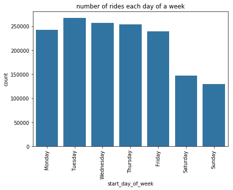

```python
df['start_day_of_week']=df['start_time'].dt.weekday
rides_per_week = df.groupby('start_day_of_week')['bike_id'].count()
plt.figure(figsize=(7,5))
sb.countplot(data=df, x='start_day_of_week', color=clr)
ticks = [0, 1, 2, 3, 4, 5, 6]
labels = ['Monday','Tuesday','Wednesday','Thursday','Friday','Saturday','Sunday']
plt.xticks(ticks, labels, rotation=90);
plt.title('number of rides each day of a week');
```

The rides through a weekday is almost double that of the weekend, with the highest rides on Tuesday.

### Which month is the busiest ?

##### As we are analyzing data for 1 year, it is important to know how the rides are distibuted among the 12 months. To do that we should extract the year and the month from the starting date, then filtering our data using them by a groupby function. Bar plot is the best way to present our data.

```python
print('minimum date', df['start_time'].min())
print('maximum date', df['start_time'].max())
```

```
minimum date 2017-06-28 09:47:36.347000
maximum date 2018-07-31 23:57:19.302000
```

```python
df['start_year']=df['start_time'].dt.year
df['start_month']=df['start_time'].dt.month
total_month = pd.DataFrame(df.groupby(['start_year','start_month'])['bike_id'].count())
```

```
Text(0,0.5,'rides count')
```

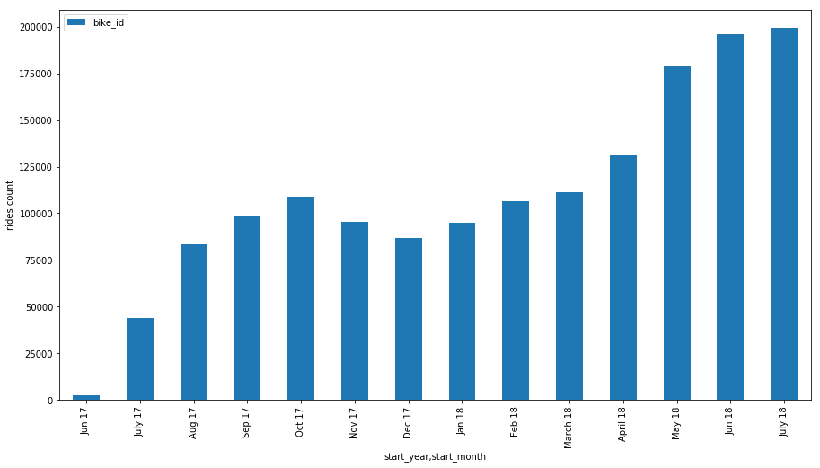

```python
total_month.plot(kind='bar' , color=clr, figsize=(15,8))
ticks = [0, 1, 2, 3, 4, 5, 6,7,8,9,10,11,12,13]
labels = ['Jun 17','July 17','Aug 17','Sep 17','Oct 17','Nov 17','Dec 17','Jan 18','Feb 18', 'March 18','April 18','May 18','Jun 18','July 18']
plt.xticks(ticks, labels, rotation=90);
plt.ylabel('rides count')
```

-Our records starts at the end of June 2017 thats why it has the lowest count, so it is not fair to include it in our analysis.

```python
df.duration_min.min()
```

```
1.0166666666666666
```

### Trip duration per rides

[figure not shown]

```python
binsize = 100
bins = np.arange(0, df['duration_min'].max()+binsize, binsize)
plt.hist(data=df, x='duration_minute', bins=bins);
```

It seems we should be more specific while plotting this figure as we have many data and points, we should use the log transformation to have clear plot.

```
Text(0,0.5,'rides count')
```

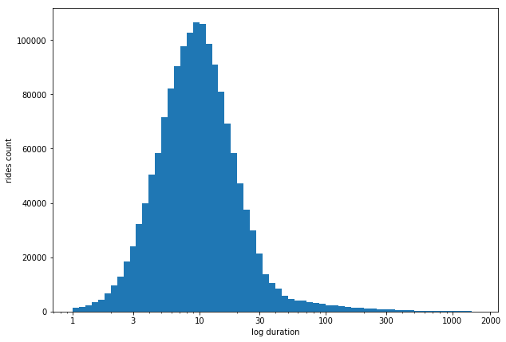

```python
log_binsize = 0.05
bins = 10 ** np.arange(0, np.log10(df['duration_min'].max())+log_binsize, log_binsize)
ticks = [1, 3, 10, 30, 100, 300, 1000, 2000]
labels = ['{}'.format(val) for val in ticks]
plt.figure(figsize=[10, 7])
plt.hist(data = df, x = 'duration_min', bins = bins)
plt.xscale('log')
plt.xticks(ticks, labels);
plt.xlabel('log duration')
plt.ylabel('rides count')
```

This graph shows that log duration is normally distibuted with some right outliers.

### Which hour of the day is the busiest?

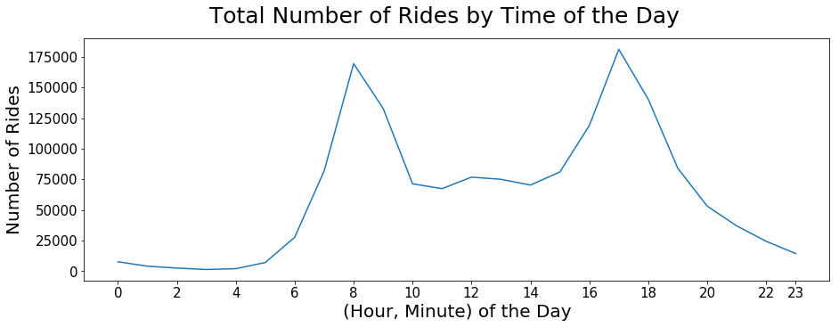

```python
df['start_hour']=df['start_time'].dt.hour
total_num_rides_by_hour = pd.DataFrame(df.groupby(['start_hour']).count()['start_station_id'])
total_num_rides_by_hour.plot(legend = None, figsize =(15,5))
plt.tick_params(labelsize=15)
ticks2 = [0, 2,4,6,8,10,12,14,16,18,20,22,23]
plt.xticks(ticks2)
plt.suptitle('Total Number of Rides by Time of the Day', size=25)
plt.ylabel('Number of Rides', size=20)
plt.xlabel('(Hour, Minute) of the Day', size=20);
```

we have 2 main peaks in the graph at 8:00 and at 17:00 where employees use the ride to go to their work and back home.

### Discuss the distribution(s) of your variable(s) of interest. Were there any unusual points? Did you need to perform any transformations?

> The histogram of the duration_min variable wasnt clear at all and shows only 1 bin, so I looked at the data using a log transform. it looks somehow normaly distibuted.

### Of the features you investigated, were there any unusual distributions? Did you perform any operations on the data to tidy, adjust, or change the form of the data? If so, why did you do this?

> When investigating the gender i filled the missing data with 'Unknown' to make it more clear with respect to the count of each one so that all our data is represented in the histograph.

# Bivariate Exploration

### How are the customers and subscribers rides are distibuted over the week?

##### By using a Bivariate countplot for 'user_type' and 'start_day_of_week' we will get a clear figure that discribes our data.

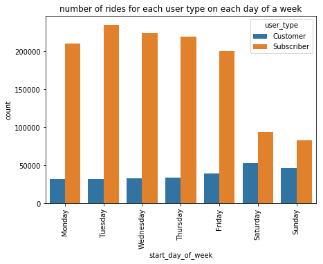

```python
df['start_day_of_week']=df['start_time'].dt.weekday
plt.figure(figsize=(7,5))
sb.countplot(data = df, x = 'start_day_of_week', hue = 'user_type');
ticks1 = [0, 1, 2, 3, 4, 5, 6]
labels1 = ['Monday','Tuesday','Wednesday','Thursday','Friday','Saturday','Sunday']
plt.xticks(ticks1, labels1, rotation=90)
plt.title('number of rides for each user type on each day of a week');
```

For sure the Subscriber are more than the customer through all the days of the week. But we can see that the customers took more rides during the weekend comparing with that through th weekdays. However subscribers took more rides during the weekdays comparing with that through the weekends.

### How are the customers and subscribers rides are distibuted among the rider gender?

##### A heat map is a good way to plot the relation between the user_type and the member_gender.

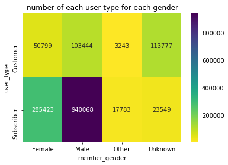

```python
type_gender = df.groupby(['member_gender', 'user_type']).size()
type_gender = type_gender.reset_index(name = 'count')
type_gender = type_gender.pivot(index = 'user_type', columns = 'member_gender', values = 'count')
sb.heatmap(type_gender,annot = True, fmt = 'd',cmap = 'viridis_r')
plt.title('number of each user type for each gender');
```

This heat maps shows the number of users type for each gender, it seems we have a lot of missing data that should be gathered in the future rides.

### What is the relation between the ride duration and the day of the week?

##### To answer this question we can plot a Bivariate boxplot figure using log transformation for the duration VS start_day_of_week.

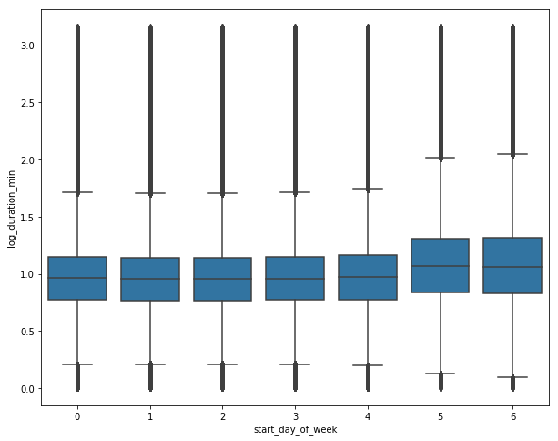

```python
plt.figure(figsize=(10,8))
df['log_duration_min'] = np.log10(df['duration_min'])
sb.boxplot(data = df, x = 'start_day_of_week', y = 'log_duration_min', color = clr);
```

Howvwe there is outliers in this boxplot, but it shows clearly that the duration of rides over the weekend are longer than the rides through the weekdays.

### Talk about some of the relationships you observed in this part of the investigation. How did the feature(s) of interest vary with other features in the dataset?

> The subscribed riders have more rides during the weekday than the weekend, while the customers have more rides during the weekends comparing with the weekdays. But in General the subscribers have more rides than the customers.

### Did you observe any interesting relationships between the other features (not the main feature(s) of interest)?

> The duration of rides during the weekends tends to be higher than that of the weekdays, and it would be better if we can get the complete gender data from the riders since we have many missing data.

# Multivariate Exploration:

### What is the relation between the ride duration, user type and day of the ride?

##### A multivariate boxplot will show us the relation between these 3 variables.

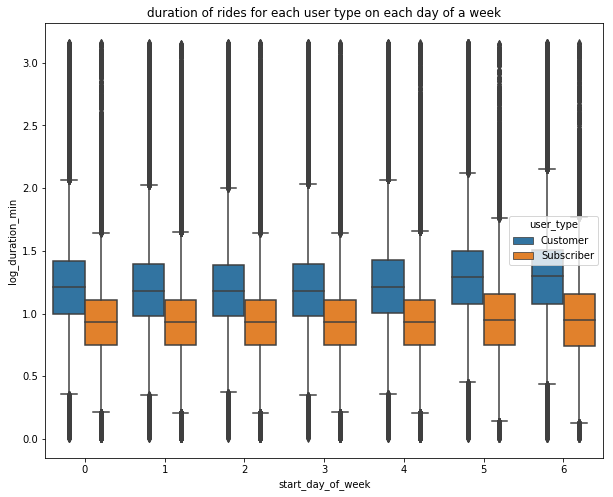

```python
plt.figure(figsize=(10,8))
sb.boxplot(data = df, x = 'start_day_of_week', y = 'log_duration_min', hue = 'user_type')
plt.title('duration of rides for each user type on each day of a week');
```

The duration of the subscriber rides are lower than that of the customer regardless the day of the week.

### What is the relation between the ride duration, member gender and day of the ride?

##### A seaborn barplot is a good way to plot and explore the relation between these three variables.

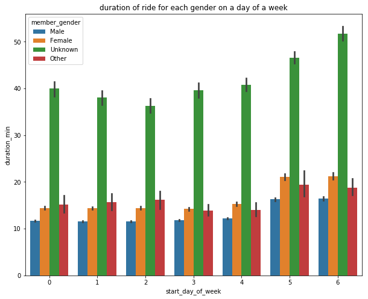

```python
plt.figure(figsize=(10,8))
sb.barplot(data = df, x = 'start_day_of_week', y = 'duration_min', hue = 'member_gender')
plt.title('duration of ride for each gender on a day of a week');
```

this multivariate barplot shows that the male rides have the lowest duration among the member_gender and those who didnt state their gender have the longest rides.

### What is the relation between the ride duration, user type and member gender?

##### A FacetGrid multivariate boxplot can clearly show us the relatoin between these variables.

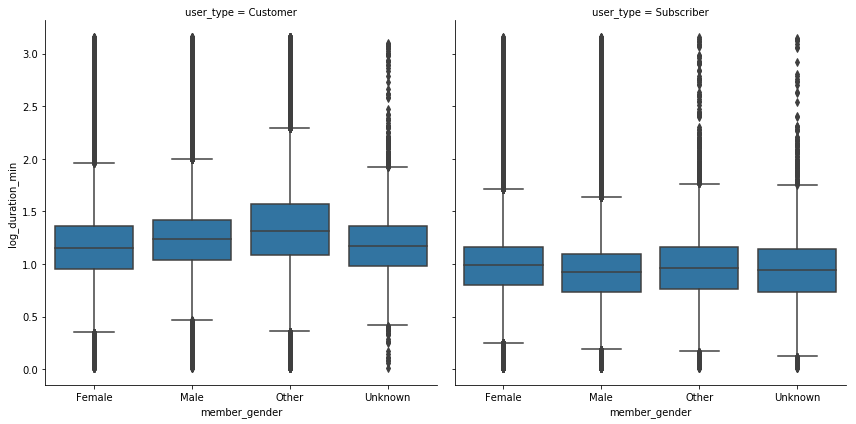

```python
g = sb.FacetGrid(data = df, col = 'user_type', size = 6)
g.map(sb.boxplot, 'member_gender', 'log_duration_min');
```

By comparing both boxplots we can conclude that the customers tends to have higher rides duration, regadless the member gender.

### Talk about some of the relationships you observed in this part of the investigation. Were there features that strengthened each other in terms of looking at your feature(s) of interest?

> Hoewever the whiskers are very tall in the boxplot showing that there is a lot of outlier durations, but it is clear that customers have longer duration rides than the subsribers all over the week.

### Were there any interesting or surprising interactions between features?

> As i said before, it would be more accurate to have all the gender data, however from those who stated their gender we can see that the females have higher diration than the males all over the week, but while exploring the facetgrid i found that the male customers have higher duration rides than the female customers but on the other hand the female subscibers have a higher duration rides than the male subsribers.

# Conclusion:

#### After making the necessary analysis and visualizations we can conclude that:

##### 1- Around 67% of the riders are males.

##### 2- Most of the riders are between age 25 and 40.

##### 3- The peak hours are 8 am and 17 pm.

##### 4- Rides through the weekdays are almost double that of the weekend.

##### 5- Customers tend to have higher rides duration than the subscriber no matter what day is it.

##### 6- Females have higher duration rides than males.

```python
# save the dataset into pkl
df.to_pickle('Ford_GoBike.pkl')
```